# Public Responses to Jihadist Terrorism on Social Media

Migration and Societal Change, Utrecht University

Christian S. Czymara

20 Jun 2025

## Introduction

- Social media shapes how societies respond to terrorist attacks
  - Emotional expression and political discourse (Bove et al. 2024; Hurtado Bodell & Menshikova 2024)
  - Increases in both hate speech (Czymara & Gorodzeisky 2024; Kaakinen et al. 2018) and solidarity (Garcia & Rimé 2019)
  - Offline effects: Far-right voting (Giavazzi et al. 2023), hate crimes (Müller & Schwarz 2021)
- Research question: *How do immigration-related discussions evolve on Twitter after Jihadist attacks?*

## Terror Management Theory

- Fear of death leads people to defend cultural worldviews (Greenberg et al., 1986; Yum & Schenck-Hamlin 2005; Fischer-Preßler et al., 2019)
- After terrorist attacks, reactions include:
  - Religious behavior, nationalism, prejudice/stereotyping
  - Counterbigotry activism, altruism, appreciation of helpers
- Focus of this study on reactions relating to migration or intergroup relations

## Topic Expectations: Nationalism & Prejudice

- *Group threat theory*: majorities may view minorities as threats after “significant events” (Blumer, 1958)
- Jihadist terror attacks can trigger exclusionary views (Legewie, 2013)
- TMT categories:
  - *Prejudice/stereotyping*: Negative outgroup sentiment
  - *Nationalism/patriotism*: Positive ingroup sentiment

## Topic Expectations: Prosocial Behavior & Counterbigotry

- Reactions to terror attacks can also include empathy, tolerance, and solidarity
- Shared trauma can strengthen intergroup bonds (*social resilience*) (Garcia & Rimé, 2019)
- TMT categories:
  - *Prosocial behavior*: Empathy, emotional support
  - *Counterbigotry activism*: Calls for tolerance, rejection of hate

## The Dynamic Nature of Topics

- Online reactions to terrorism shift over time
  - Hate speech and negative emotions peak early, then decline (Czymara & Gorodzeisky, 2024; Garcia & Rimé, 2019)
  - Solidarity and opinion-driven content emerge later (Fischer-Preßler et al., 2019)
- *Nationalism and prejudice are expected to peak early, followed by a rise in prosocial behavior and counterbigotry*

## Overview of attacks

| City | Date | Attack | Deaths | Injuries | Abbreviation |
| --- | --- | --- | --- | --- | --- |
| Paris (FR) | 7–9 Jan 2015 | Charlie Hebdo + kosher supermarket shootings | 17 | 19 | FR15_CH |
| Paris (FR) | 13 Nov 2015 | Bataclan shootings and other attacks | 137 | 413 | FR15_BATA |
| Brussels (BE) | 22 Mar 2016 | Airport and metro station bombings | 32 | 340 | BE16 |
| Nice (FR) | 14 Jul 2016 | Bastille Day truck attack | 87 | 270 | FR16 |
| Berlin (DE) | 19 Dec 2016 | Christmas market truck attack | 13 | 48 | DE16 |
| London (UK) | 22 Mar 2017 | Westminster Bridge attack | 5 | 48 | UK17_west |
| Manchester (UK) | 22 May 2017 | Manchester Arena bombing | 22 | 239 | UK17_man |
| London (UK) | 3 Jun 2017 | London Bridge attack | 8 | 48 | UK17_lon |
| Barcelona (ES) | 17 Aug 2017 | Van attacks | 15 | 104 | ES17 |
| Strasbourg (FR) | 11 Dec 2018 | Christmas market attack | 5 | 11 | FR18 |
| Vienna (AT) | 02 Nov 2020 | Shootings | 5 | 22 | AT20 |

## Search string

- Identify Tweets that deal with migration related topics, including Muslims (much debated migrant group), but no direct search for insults or derogatory terms, nor attack specific hashtags
- Language-specific search string, English version (all accessible at osf.io/zdt5b):

```
 [1] "migration"   "immigration" "migrant"     "immigrant"   "foreigner"
 [6] "migrants"    "immigrants"  "foreigners"  "refugee"     "refugees"
[11] "asylum"      "islam"       "islamist"    "islamism"    "muslim"
[16] "muslims"     "salafist"    "Salafism"    "jihad"
```

- Accounts located in the city of each attack took place

## Distribution of Tweets

- 102173 Tweets posted by 36390 accounts

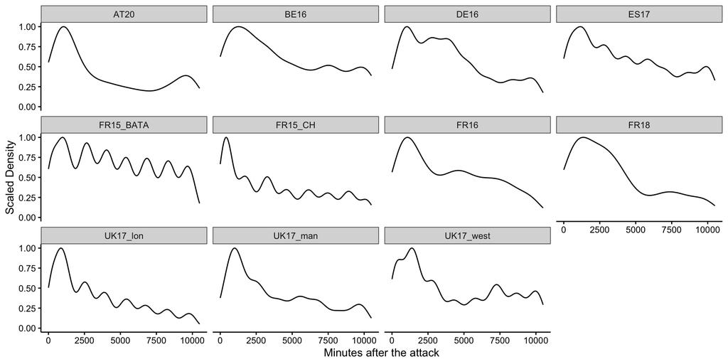

# Method

## Keyword-Assisted Topic Modelling

- keyATM (Eshima et al., 2024) is a semi-supervised model using predefined keywords (identifying both expected and unexpected topics)
- Uses keywords to initialize the model, which then refines the topics based on the data
- Reduces subjectivity by directly targeting theoretical concepts
- Less sensitive to topic number specification

## Topic Identification

- Focus on TMT reactions tied to intergroup dynamics:
  - *Nationalism*: National pride, anti-immigrant sentiment
  - *Prejudice*: Stereotypes of minorities as violent or threatening
  - *Counterbigotry*: Rejection of hate, emphasis on tolerance and solidarity
  - *Prosocial*: Empathy and support for victims and affected communities

## Keywords

- Keywords selected based on prior research and empirical validation

| Language | Nationalism | Prejudice | Counterbigotry | Prosocial |
| --- | --- | --- | --- | --- |
| English | proud, tradition, culture, patriot, patriotic | criminal, danger, illegal, violence, violent, threat, barbarism | love, peace, tolerance, racist, racism, solidarity | victims, relatives, thoughts, condolences, sympathy, mourn |
| French | fier, fière, fiers, culture, tradition, patriote, patriotique | criminelle, illégale, violence, violente, menace, barbarie | amour, paix, tolérance, raciste, racisme, solidarité | victimes, proches, pensées, condoléances, sympathies, deuil |
| German | stolz, tradition, kultur, patriot, patriotisch, volk | kriminell, gefahr, illegal, gewalt, gewalttätig, bedrohung, barbarei | liebe, frieden, toleranz, rassist, rassismus, hetze, solidarität | opfer, angehörige, gedanken, gedenken, beileid, trauer |
| Spanish | orgulloso, tradición, cultura, patriota, patriótico | criminal, peligro, ilegal, violencia, violenta, amenaza, barbarie | amor, paz, tolerancia, racista, racismo, solidaridad | victima, relatives, pensamientos, condolencia, pésame, dolor |

## Final Model

- Lowercasing, stemming, removing stopwords, top 15 most frequent terms per language, @mentions, punctuation, numbers, symbols, URLs
- *Covariate keyATM* to examine temporal variation: Dummy predictor (first 2 days vs. days 3–7)
- In addition to 4 keyword-based topics, 20 non-keyword topics estimated
- Separate models for each language

## Validation

- Annotated 150 most representative Tweets for each topic-language combination (based document-topic distribution $\theta$)
- Zero-shot classification with GPT-3.5-turbo-0125 with manually validation
- On average, each topic overlapped 70 percent with the GPT classification
  - 49 percent (Nationalism in English, Prosocial in French)
  - 89 percent (Prejudice in French and German)

# Results

## keyATM Results: English

```
   1_nationalism 2_prejudice 3_counterbigotry 4_prosocial Other_1 Other_2
1     cultur [✓]      muslim           muslim      muslim  muslim  immigr
2         muslim       islam            islam      attack  immigr  brexit
3         immigr violent [✓]         peac [✓]  victim [✓]   islam      eu
4          islam violenc [✓]         love [✓]      london  refuge  refuge
5         refuge        true       racist [✓]       islam  attack  muslim
6         migrat        call            peopl      terror  brexit migrant
7     tradit [✓]        rape         religion   terrorist migrant  migrat
8        migrant  crimin [✓]        terrorist       peopl   peopl    vote
9       religion  threat [✓]           terror   westminst countri foreign
10         chang   illeg [✓]             hate   communiti british    leav
     Other_3   Other_4   Other_5   Other_6  Other_7 Other_8 Other_9  Other_10
1     muslim    muslim    muslim    immigr   muslim  muslim  muslim    muslim
2      islam     islam     islam    muslim    islam  immigr  refuge     islam
3     terror    refuge    repres    refuge   refuge  refuge  immigr     peopl
```

[output cut: 29 more lines]

## keyATM Results: French

```
   1_nationalism  2_prejudice 3_counterbigotry  4_prosocial  Other_1  Other_2
1          islam   barbar [✓]         musulman     musulman musulman musulman
2         djihad     musulman         paix [✓]   victim [✓]    franc   réfugi
3       musulman    menac [✓]          l'islam        c'est    islam   djihad
4          franc      l'islam            c'est     pens [✓]   djihad   syrien
5     cultur [✓]        islam         religion      l'islam    c'est    franc
6      anonymous        franc           terror       terror  l'islam    islam
7            sit  violenc [✓]            islam        islam   terror   terror
8        l'islam       terror       racist [✓]        franc    charl  l'islam
9          charl criminel [✓]             juif charliehebdo    paris    paris
10         jihad         acte            franc        qu'il    hebdo attentat
    Other_3      Other_4  Other_5  Other_6  Other_7  Other_8  Other_9
1  musulman     musulman    franc   djihad musulman   djihad musulman
2     franc        islam   djihad musulman   djihad    islam    c'est
3     c'est      l'islam musulman    islam    franc musulman    franc
```

[output cut: 29 more lines]

## keyATM Results: German

```
   1_nationalism  2_prejudice 3_counterbigotry  4_prosocial          Other_1
1           asyl   gewalt [✓]         hetz [✓]      opf [✓]     fluchtling
2           turk  illegal [✓]    rassismus [✓]       muslim            islam
3    deutschland   gefahr [✓]        fried [✓]     trau [✓]           berlin
4      stolz [✓]       muslim           muslim   gedenk [✓]       asylbewerb
5         turkei fluchtling            islam        islam           muslim
6       beantrag    migration         lieb [✓]       berlin         anschlag
7         muslim    einwander       islamismus fluchtling           terror
8   fluchtling         asyl     fluchtling     anschlag        terrorist
9          islam         wien           terror     islamist breitscheidplatz
10          land     turkisch            glaub       terror      deutschland
        Other_2      Other_3      Other_4      Other_5          Other_6
1  fluchtling fluchtling        islam fluchtling     fluchtling
2        terror      deutsch       muslim        islam           berlin
3         islam        islam fluchtling        polit       asylbewerb
```

[output cut: 40 more lines]

## keyATM Results: Spanish

```
   1_nationalism  2_prejudice 3_counterbigotry 4_prosocial  Other_1  Other_2
1     cultur [✓]   amenaz [✓]         musulman    musulman    yihad musulman
2       musulman     musulman            islam  victim [✓] musulman    yihad
3     orgull [✓] violenci [✓]          paz [✓]      terror     moss   terror
4          islam        islam           terror       islam      via    atent
5         inmigr  violent [✓]       racist [✓]       yihad    polic barcelon
6        necesit        yihad         religion    barcelon    atent    islam
7          abraz       terror         barcelon   dolor [✓] barcelon      via
8           padr        atent       racism [✓]      refugi    alert    celul
9           años         vide         amor [✓]       atent investig    comun
10         muert criminal [✓]            yihad        gent   terror   ripoll
     Other_3   Other_4  Other_5   Other_6   Other_7   Other_8   Other_9
1      yihad  musulman    islam     yihad  musulman  musulman     yihad
2   musulman extranjer musulman       via    terror     yihad     islam
3      islam     yihad    yihad  musulman     yihad     islam  musulman
```

[output cut: 29 more lines]

## Overall Prevalence of Keyword Topics

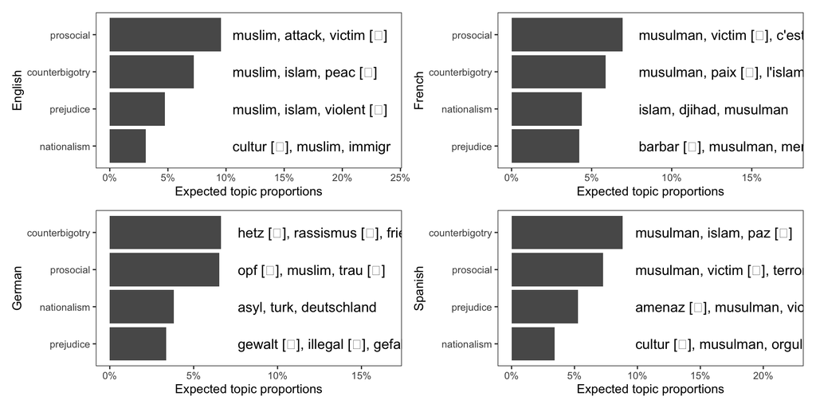

## Changes in Topics Over Time

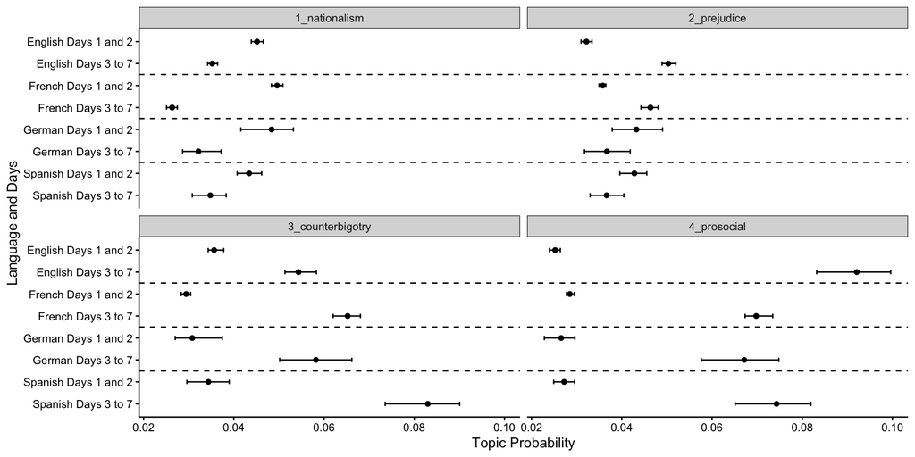

# Summing up

## Conclusion

- Terrorist attacks can trigger both exclusion and solidarity online
- Nationalism peaked shortly after attacks, inclusionary topics gained prominence over time
- Social media reveals shifts not easily captured in survey data
- Limitations
  - Hate speech likely underrepresented due to platform deletions
  - X’s changing user base (e.g. after Musk’s takeover) likely limits generalizability

## Preprint

- Available on SocArXiv at [doi.org/10.31235/osf.io/fkue4_v1](https://osf.io/preprints/socarxiv/fkue4_v1)